# Amortized R(t): behavioral SIR models across all US states

`vignette("sir-epidemic")` fits a stochastic SIR outbreak with a *constant* contact rate $\beta$. Real epidemics do not hold still, and the interesting question is *why* they move. Control measures, voluntary behavior change, and depleting susceptibles all push transmission around over the course of an outbreak, and different mechanisms leave different fingerprints on the case curve.

This vignette fits **three competing models** of that mechanism to daily reported cases in all 50 US states plus Washington, DC, over the first 120 days of the SARS-CoV-2 pandemic (2020-01-21 to 2020-05-19). Two of them are behavioral-feedback models taken from Gozzi, Perra and Vespignani’s comparative study (2025, *PNAS* 122(24) e2421993122), where transmission responds to what people can see happening around them. The third is a phenomenological baseline that simply lets $\beta$ take a different constant value in each of a few time regimes. Each is trained **once**, amortized over the prior, and then conditioned on 51 different state curves for the price of a forward pass each. That is what makes a three-model, 51-jurisdiction comparison affordable at all.

Along the way the vignette answers the question public-health teams actually care about — how did the **effective reproduction number** $R_e(t) = \beta(t) S(t) / (N \gamma)$ evolve? — and shows two pieces of `neuralsbi` machinery that matter for time-series inference: an `embedding_mlp()` summary network, and a prior predictive check that catches the kind of model error no amount of training will fix.

## The data: daily reported cases in the first 120 days

We use the New York Times’ state-level COVID-19 case counts, which start on 2020-01-21 — the date of the first confirmed US case (Snohomish County, Washington) — and US Census population estimates.

```r
cases_url <- "https://raw.githubusercontent.com/nytimes/covid-19-data/master/us-states.csv"
pop_url <- "https://raw.githubusercontent.com/COVID19Tracking/associated-data/master/us_census_data/us_census_2018_population_estimates_states.csv"

raw_cases <- read.csv(cases_url)
pop_table <- read.csv(pop_url)

raw_cases$date <- as.Date(raw_cases$date)
start_date <- as.Date("2020-01-21")
days <- 120L
end_date <- start_date + days - 1L
window <- raw_cases[raw_cases$date >= start_date & raw_cases$date <= end_date, ]

# the 50 states + DC only -- drop territories (Puerto Rico is the only one the
# population table also carries, so it needs an explicit exclusion)
state_names <- sort(setdiff(intersect(unique(window$state), pop_table$state_name),
                            "Puerto Rico"))
window <- window[window$state %in% state_names, ]
length(state_names)
```

```
#> [1] 51
```

The NYT series is cumulative, and it is not monotone: data revisions occasionally push the running total down. We difference it to daily new cases, clipping the revision artifacts at zero.

```r
daily_cases <- function(state_df) {
  full <- data.frame(date = seq(start_date, end_date, by = "day"))
  full <- merge(full, state_df[, c("date", "cases")], by = "date", all.x = TRUE)
  full$cases[is.na(full$cases)] <- 0
  full$cases <- cummax(full$cases)             # enforce a monotone cumulative count
  new <- c(full$cases[1], diff(full$cases))
  new[new < 0] <- 0                            # data-revision artifacts
  new
}

case_daily <- t(sapply(state_names, function(s) daily_cases(window[window$state == s, ])))
rownames(case_daily) <- state_names
pop <- stats::setNames(pop_table$population, pop_table$state_name)[state_names]
dim(case_daily)
```

```
#> [1]  51 120
```

```r
range(pop)
```

```
#> [1]   577737 39557045
```

Daily counts carry a strong weekday cycle — fewer tests processed and fewer results reported at weekends — that no SIR model generates and none of these models should be asked to fit. We take a **centred 7-day mean** as the summary statistic, and the key point is that we will apply the *same* smoother to simulated data. The network then learns $p(\theta \mid s(x))$ for a summary $s$ that means the same thing on both sides; smoothing only the observation would be a fudge, and the simulated and observed data would no longer be comparable.

```r
smooth7 <- function(m) {
  m <- if (is.matrix(m)) m else matrix(m, nrow = 1)
  out <- m
  for (i in seq_len(ncol(m))) {
    idx <- max(1L, i - 3L):min(ncol(m), i + 3L)
    out[, i] <- rowMeans(m[, idx, drop = FALSE])
  }
  out
}
case_daily_s <- smooth7(case_daily)
```

State populations span two orders of magnitude, from Wyoming (577,737) up to California (39,557,045). That range matters below: population size is a *known* covariate, not something we infer, but one amortized posterior has to condition on it correctly for a 39-million-person state and a 600,000-person state alike.

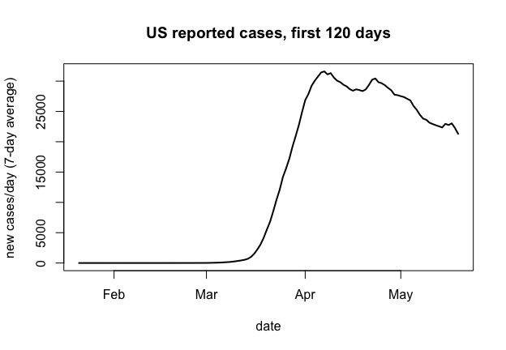

```r
national <- aggregate(cases ~ date, data = window, sum)
national <- national[order(national$date), ]
national$new <- pmax(c(national$cases[1], diff(national$cases)), 0)
national$new7 <- as.numeric(smooth7(national$new))
national$day <- as.numeric(national$date - start_date) + 1

plot(national$date, national$new7, type = "l", lwd = 2,
     xlab = "date", ylab = "new cases/day (7-day average)",
     main = "US reported cases, first 120 days")
```

## Three mechanisms, one core

All three models share the same discrete-time, binomial-transition SIR core used in `vignette("sir-epidemic")`: susceptible, infected, and recovered counts update via `rbinom()`, so the process is genuinely stochastic and there is no tractable likelihood for the reported-case curve. Susceptibles deplete — every infection removes someone from $S$, and that feedback is what separates the *effective* reproduction number from the contact rate. Three ingredients are shared by all three models and are worth stating before the mechanisms that differ.

**The epidemic starts when it starts.** The day the virus arrives, $t_0$, and the number of infections $I_0$ that arrive with it are **inferred**, not fixed. Seeding every state with a couple of infections on 2020-01-21 gets the epidemiology wrong twice over. It is wrong about the world — Washington’s outbreak was seeded in January, West Virginia did not report a case until March 17 — and it is wrong about what a two-infection seed does to a 120-day simulation. A supercritical branching process started from two individuals has a substantial extinction probability and, conditional on survival, a final size spread over orders of magnitude; the *timing* of takeoff then wanders by weeks. Replicate simulations at a single fixed $\theta$ differ by a factor of several thousand at the peak. Inferring $(t_0, I_0)$ pins the phase with a parameter instead of leaving it to luck, and it is the more faithful model besides: states were seeded by many independent importations, not by a single index case.

**Ascertainment is pinned by seroprevalence, not left free.** Only a fraction $\rho$ of infections became a confirmed case in spring 2020. $\rho$ is inferred, but with an *informative* prior, and that is not optional. Reported case counts identify the product $\rho \times \text{incidence}$, not either factor: a small, well-ascertained epidemic and an enormous, barely-ascertained one produce the same curve. Left to itself the fit takes the second branch, because susceptible depletion is then available to flatten the peak cheaply, which drives $\rho$ into the low thousandths and the attack rate close to 1. Serology settles it from outside the case data: CDC’s large-scale commercial-lab study put spring-2020 infections at roughly 6 to 24 times reported cases across 10 US sites (Havers et al. 2020, *JAMA Internal Medicine*), i.e. $\rho$ between about 0.04 and 0.17. We encode that as a logit-normal prior centered at 0.10 with 95% mass in $[0.05, 0.19]$.

**Population size $N$ is a known covariate.** The simulator draws it from a distribution spanning real US state sizes during training, and the estimator conditions on $\log N$ alongside the case curve, so one trained network generalizes from Wyoming to California. The recovery rate $\gamma$ is **fixed**: with only case counts the generation interval is not separately identifiable from $\beta(t)$, so we set $1/\gamma = 7$ days, in line with early estimates of the COVID-19 serial interval (Li et al. 2020, *NEJM*).

```r
library(neuralsbi)
gamma_fixed <- 1 / 7
t_grid <- seq_len(days)
PER <- 1e5                      # behavioral drivers are per 100,000 people
```

### Model 1 — piecewise-constant $\beta(t)$ (the phenomenological baseline)

The first model makes no claim about *why* transmission changed: it lets $\log\beta$ take a different constant value in each of a few time regimes, blending between them over a smooth, roughly one-week logistic transition (policy roll-out and behavior change unfold over days, not instantaneously). It is a flexible curve fit, and it is the arm the other two have to beat.

How many regimes, and where do the boundaries go? We answer that from the national curve rather than by assumption, fitting a continuous piecewise-linear regression to `log(new7)` and selecting breakpoints by BIC.

```r
nat <- national[national$new7 > 0, ]
y <- log(nat$new7); day <- nat$day; n_obs <- length(y)

fit_bic <- function(taus) {
  X <- cbind(1, day, sapply(taus, function(tau) pmax(day - tau, 0)))
  fit <- lm.fit(X, y)
  if (any(is.na(fit$coefficients))) return(NULL)
  rss <- sum(fit$residuals^2); p <- ncol(X)
  list(bic = n_obs * log(rss / n_obs) + p * log(n_obs), taus = taus)
}

cand <- seq(10, 110, by = 5)
best_by_k <- lapply(0:6, function(k) {
  if (k == 0) return(fit_bic(numeric(0)))
  combs <- combn(cand, k); best <- NULL
  for (j in seq_len(ncol(combs))) {
    r <- fit_bic(combs[, j])
    if (!is.null(r) && (is.null(best) || r$bic < best$bic)) best <- r
  }
  best
})

knot_table <- data.frame(
  breakpoints = 0:6,
  bic = sapply(best_by_k, `[[`, "bic"),
  taus = sapply(best_by_k, function(b) paste(b$taus, collapse = ", ")))
knot_table$delta_bic <- c(NA, -diff(knot_table$bic))
knot_table
```

```
#>   breakpoints         bic                   taus delta_bic
#> 1           0  144.998766                               NA
#> 2           1    6.394732                     75 138.60403
#> 3           2 -246.682972                 25, 70 253.07770
#> 4           3 -309.095418             20, 40, 65  62.41245
#> 5           4 -332.116366         20, 40, 60, 70  23.02095
#> 6           5 -360.414111     10, 20, 40, 60, 70  28.29775
#> 7           6 -373.016481 15, 20, 25, 35, 65, 75  12.60237
```

```r
knot_days <- c(1, sort(best_by_k[[4]]$taus), days)
knot_days
```

```
#> [1]   1  20  40  65 120
```

```r
n_segments <- length(knot_days) - 1L
nominal_dur <- diff(knot_days)
total_days <- sum(nominal_dur)
transition_scale <- 7 / 4
```

The breakpoints get **wiggle room per state**: community transmission did not take hold, and stay-at-home orders did not land, on the same calendar day everywhere. Rather than move each breakpoint independently — which risks two adjacent breakpoints crossing — we put a prior on each regime’s *duration* and take the breakpoints as cumulative sums, so the regimes tile the window in order for every draw. Only 3 of the 4 durations are free: the simulator rescales them to span the window exactly, so their common scale does nothing. Parameterizing the free directions directly (three log-ratios against the last regime) keeps every coordinate of $\theta$ identified — a fourth would be pure noise for the flow to model, and SBC would not catch it, because an unidentified coordinate returns its prior and looks perfectly calibrated.

```r
beta_piecewise <- function(log_beta_segments, log_dur_ratio) {
  n <- nrow(log_beta_segments)
  w <- cbind(exp(log_dur_ratio), 1)
  dur <- w / rowSums(w) * total_days
  tau <- knot_days[1] + t(apply(dur, 1, cumsum))[, seq_len(n_segments - 1L), drop = FALSE]
  w_ext <- c(list(matrix(1, n, days)),
             lapply(seq_len(n_segments - 1L), function(k) {
               outer(tau[, k], t_grid, function(a, t) plogis((t - a) / transition_scale))
             }),
             list(matrix(0, n, days)))
  exp(Reduce(`+`, lapply(seq_len(n_segments), function(j) {
    (w_ext[[j]] - w_ext[[j + 1]]) * log_beta_segments[, j]
  })))
}
```

### Models 2 and 3 — behavioral feedback

Gozzi, Perra and Vespignani (2025) compare mechanistic behavioral epidemic models against data-driven ones across nine cities and the first COVID-19 wave. Their two *analytical* feedback models need no external mobility data — transmission responds to the epidemic’s own reported output — which makes both of them self-contained simulators, exactly what SBI wants.

**EFB (effective force of infection).** The force of infection is divided by a factor that grows with what people have recently seen and with what they have seen cumulatively:
$$\lambda(t) = \beta_0 \frac{I(t)}{N} \cdot
\frac{1}{1 + \xi\, c(t-1) + \psi \sum_{t' < t} c(t')} .$$
$\xi$ is reactivity to the current news, $\psi$ to accumulated experience. Six parameters in total.

**CBF (compartmental behavioral feedback).** Susceptibles move into a risk-averse compartment $S_B$ at rate $\beta_B (1 - e^{-g\,c(t-1)})$, drift back at rate $\mu_B$, and while in $S_B$ their force of infection is scaled by $r < 1$. Behavior here is a *state* of the population that takes time to build and to decay, rather than an instantaneous function of the news. Eight parameters.

Two adaptations to the paper’s specification, both forced by what we are doing here. The paper drives behavior off reported **deaths**; we drive it off reported **cases**, which is the only outcome this model generates and was itself a headline number in spring 2020. And we express the driver $c(t)$ **per 100,000 people** rather than as a raw count, because a single amortized posterior has to serve Wyoming and California: behavior responds to perceived local risk, which scales with per-capita incidence. With a raw-count driver the same $\xi$ would mean drastically different behavior in a small state and a large one, and no single $\xi$ could fit both.

```r
draw_N <- function(n, N_fixed) {
  if (is.null(N_fixed)) exp(stats::runif(n, log(5e5), log(4e7))) else rep(N_fixed, n)
}

# x = log(N) followed by the 7-day-smoothed daily reported cases, log1p'd.
pack <- function(N, reported, S_frac, beta_eff, full) {
  x <- cbind(log(N), log1p(smooth7(reported)))
  if (!full) return(x)
  list(x = x, reported = reported, S_frac = S_frac, beta_eff = beta_eff)
}

# shared: introduce the epidemic at t0 with a Poisson(seed_mean) seed
seed_step <- function(t, t0, seed_mean, S, I, seeded) {
  fresh <- !seeded & (t >= t0)
  if (any(fresh)) {
    s0 <- pmin(stats::rpois(sum(fresh), seed_mean[fresh]), S[fresh])
    I[fresh] <- I[fresh] + s0
    S[fresh] <- S[fresh] - s0
    seeded[fresh] <- TRUE
  }
  list(S = S, I = I, seeded = seeded)
}
```

```r
sim_pw <- function(theta, N_fixed = NULL, full = FALSE) {
  theta <- matrix(as.numeric(theta), ncol = 10L)
  n <- nrow(theta)
  beta_t <- beta_piecewise(theta[, 1:4, drop = FALSE], theta[, 5:7, drop = FALSE])
  t0 <- 1 + (days - 1) * plogis(theta[, 8])
  seed_mean <- exp(theta[, 9]); rho <- plogis(theta[, 10])
  N <- draw_N(n, N_fixed)

  S <- N; I <- rep(0, n); seeded <- rep(FALSE, n)
  reported <- matrix(0, n, days); S_frac <- matrix(0, n, days)
  n_sub <- 2L; dt <- 1 / n_sub; p_rec <- 1 - exp(-gamma_fixed * dt)
  for (t in t_grid) {
    st <- seed_step(t, t0, seed_mean, S, I, seeded); S <- st$S; I <- st$I; seeded <- st$seeded
    H <- rep(0, n)
    for (s in seq_len(n_sub)) {
      p_inf <- pmin(pmax(1 - exp(-beta_t[, t] * I / N * dt), 0), 1)
      dSI <- stats::rbinom(n, pmax(round(S), 0), p_inf)
      dIR <- stats::rbinom(n, pmax(round(I), 0), p_rec)
      S <- S - dSI; I <- I + dSI - dIR; H <- H + dSI    # susceptibles deplete
    }
    S_frac[, t] <- S / N
    reported[, t] <- stats::rbinom(n, pmax(round(H), 0), rho)
  }
  pack(N, reported, S_frac, beta_t, full)
}

sim_efb <- function(theta, N_fixed = NULL, full = FALSE) {
  theta <- matrix(as.numeric(theta), ncol = 6L)
  n <- nrow(theta)
  beta0 <- exp(theta[, 1]); xi <- exp(theta[, 2]); psi <- exp(theta[, 3])
  t0 <- 1 + (days - 1) * plogis(theta[, 4])
  seed_mean <- exp(theta[, 5]); rho <- plogis(theta[, 6])
  N <- draw_N(n, N_fixed)

  S <- N; I <- rep(0, n); seeded <- rep(FALSE, n)
  c_prev <- rep(0, n); C_cum <- rep(0, n)
  reported <- matrix(0, n, days); S_frac <- matrix(0, n, days)
  beta_eff <- matrix(0, n, days)
  n_sub <- 2L; dt <- 1 / n_sub; p_rec <- 1 - exp(-gamma_fixed * dt)
  for (t in t_grid) {
    st <- seed_step(t, t0, seed_mean, S, I, seeded); S <- st$S; I <- st$I; seeded <- st$seeded
    bt <- beta0 / (1 + xi * c_prev + psi * C_cum)      # the behavioral response
    beta_eff[, t] <- bt
    H <- rep(0, n)
    for (s in seq_len(n_sub)) {
      p_inf <- pmin(pmax(1 - exp(-bt * I / N * dt), 0), 1)
      dSI <- stats::rbinom(n, pmax(round(S), 0), p_inf)
      dIR <- stats::rbinom(n, pmax(round(I), 0), p_rec)
      S <- S - dSI; I <- I + dSI - dIR; H <- H + dSI
    }
    S_frac[, t] <- S / N
    rep_t <- stats::rbinom(n, pmax(round(H), 0), rho)
    reported[, t] <- rep_t
    c_prev <- rep_t / N * PER                          # per 100k, so one xi fits every state
    C_cum <- C_cum + c_prev
  }
  pack(N, reported, S_frac, beta_eff, full)
}

sim_cbf <- function(theta, N_fixed = NULL, full = FALSE) {
  theta <- matrix(as.numeric(theta), ncol = 8L)
  n <- nrow(theta)
  beta0 <- exp(theta[, 1]); betaB <- exp(theta[, 2]); g <- exp(theta[, 3])
  r <- plogis(theta[, 4]); muB <- exp(theta[, 5])
  t0 <- 1 + (days - 1) * plogis(theta[, 6])
  seed_mean <- exp(theta[, 7]); rho <- plogis(theta[, 8])
  N <- draw_N(n, N_fixed)

  S <- N; SB <- rep(0, n); I <- rep(0, n); seeded <- rep(FALSE, n)
  c_prev <- rep(0, n)
  reported <- matrix(0, n, days); S_frac <- matrix(0, n, days)
  beta_eff <- matrix(0, n, days)
  n_sub <- 2L; dt <- 1 / n_sub; p_rec <- 1 - exp(-gamma_fixed * dt)
  for (t in t_grid) {
    st <- seed_step(t, t0, seed_mean, S, I, seeded); S <- st$S; I <- st$I; seeded <- st$seeded
    pB <- betaB * (1 - exp(-g * c_prev))               # awareness-driven uptake
    H <- rep(0, n)
    for (s in seq_len(n_sub)) {
      lam <- beta0 * I / N
      # a susceptible faces competing risks -- infection or adopting safer
      # behavior -- so draw the total departures and split them, rather than
      # letting whichever event is applied first pre-empt the other
      tot_haz <- lam + pB
      dS <- stats::rbinom(n, pmax(round(S), 0),
                          pmin(pmax(1 - exp(-tot_haz * dt), 0), 1))
      dSI <- stats::rbinom(n, dS, ifelse(tot_haz > 0, lam / tot_haz, 0))
      dSB <- dS - dSI
      dBI <- stats::rbinom(n, pmax(round(SB), 0),
                           pmin(pmax(1 - exp(-r * lam * dt), 0), 1))
      dBS <- stats::rbinom(n, pmax(round(SB) - dBI, 0),
                           pmin(pmax(1 - exp(-muB * dt), 0), 1))
      dIR <- stats::rbinom(n, pmax(round(I), 0), p_rec)
      S <- S - dS + dBS; SB <- SB + dSB - dBI - dBS
      I <- I + dSI + dBI - dIR; H <- H + dSI + dBI
    }
    S_frac[, t] <- (S + SB) / N
    # transmission rate averaged over the susceptible pool, for reporting R_e
    beta_eff[, t] <- beta0 * (S + r * SB) / pmax(S + SB, 1)
    rep_t <- stats::rbinom(n, pmax(round(H), 0), rho)
    reported[, t] <- rep_t
    c_prev <- rep_t / N * PER
  }
  pack(N, reported, S_frac, beta_eff, full)
}
```

The priors. Every parameter is unconstrained on $\mathbb{R}$ — the log/logit transforms mean a single Gaussian prior with no truncated support, so the posterior needs no rejection sampling for leakage. Naming each `mean` vector carries the names through every posterior draw, SBC result, and diagnostic plot. Note that $\beta_0$ means different things in the two families: in the piecewise model it is an *effective* rate per regime, so its prior is centred on $R = 2$ and deliberately wide in both directions; in the behavioral models it is the *intrinsic* transmission rate with the decline explained mechanistically, so it is centred on $R_0 = 3$, the wild-type value.

```r
prior_pw <- prior_normal(
  mean = stats::setNames(
    c(rep(log(0.28), n_segments),
      log(nominal_dur[-n_segments] / nominal_dur[n_segments]),
      qlogis(35 / days), log(30), qlogis(0.10)),
    c(paste0("beta[", seq_len(n_segments), "]"),
      paste0("d[", seq_len(n_segments - 1L), "]"), "t[0]", "I[0]", "rho")),
  sd = c(rep(0.6, n_segments), rep(0.35, n_segments - 1L), 1.1, 1.2, 0.4))

prior_efb <- prior_normal(
  mean = stats::setNames(
    c(log(3 * gamma_fixed), log(0.05), log(0.001),
      qlogis(35 / days), log(30), qlogis(0.10)),
    c("beta[0]", "xi", "psi", "t[0]", "I[0]", "rho")),
  sd = c(0.30, 1.5, 1.5, 1.1, 1.2, 0.4))

prior_cbf <- prior_normal(
  mean = stats::setNames(
    c(log(3 * gamma_fixed), log(0.1), log(0.5), qlogis(0.3), log(0.02),
      qlogis(35 / days), log(30), qlogis(0.10)),
    c("beta[0]", "beta[B]", "g", "r", "mu[B]", "t[0]", "I[0]", "rho")),
  sd = c(0.30, 1.0, 1.5, 1.0, 1.0, 1.1, 1.2, 0.4))
```

## Summarizing 120 days with an embedding network

The observation is 121 numbers: $\log N$ plus a 120-day case curve. Feeding that straight into the flow wastes capacity — the flow would have to learn, from the conditioning path alone, that neighboring days are nearly redundant. The alternative most tutorials reach for is to hand-pick summary statistics (bin the curve into weeks, take a growth rate and a peak height), which throws away whatever the hand-picked set failed to capture.

`embedding_mlp()` does the compression by learning it. It is a small MLP mapping the standardized 121-dimensional observation to `output_dim` features, trained **jointly** with the density estimator, so the features are optimized for exactly one thing: predicting $\theta$. The estimator then conditions on those features rather than on the raw curve.

```r
embed <- embedding_mlp(output_dim = 12L, hidden = c(64L, 64L))
embed
```

```
#> $type
#> [1] "mlp"
#>
#> $output_dim
#> [1] 12
#>
#> $hidden
#> [1] 64 64
#>
#> attr(,"class")
#> [1] "nsbi_embedding"
```

## Check the prior predictive before training anything

Amortized NPE learns $p(\theta \mid x)$ over the *prior predictive* distribution of $x$. Data that the prior predictive essentially never produces sit in a region where the trained network is extrapolating, and its posterior there is not to be trusted — no amount of training fixes that. So before spending a simulation budget, check that each model can produce curves like the ones we intend to condition on.

```r
set.seed(11)
n_pp <- 1500
sims <- list(PW = list(sim = sim_pw, prior = prior_pw),
             EFB = list(sim = sim_efb, prior = prior_efb),
             CBF = list(sim = sim_cbf, prior = prior_cbf))

pp_check <- function(m, state) {
  theta <- sample_prior(m$prior, n_pp)
  lx <- m$sim(theta, N_fixed = pop[[state]])[, -1, drop = FALSE]   # already log1p
  d <- rowMeans(abs(lx - rep(log1p(case_daily_s[state, ]), each = n_pp)))
  mean(d < 1)
}
round(sapply(sims, function(m) sapply(c("New York", "Michigan", "West Virginia"),
                                      function(s) pp_check(m, s))), 4)
```

```
#>                   PW    EFB    CBF
#> New York      0.0553 0.1760 0.0893
#> Michigan      0.0320 0.2373 0.0927
#> West Virginia 0.1187 0.2233 0.1760
```

The number to watch is what fraction of prior draws land within a factor of $e$ of the observed curve, averaged over the 120 days. It is small — these priors are deliberately vague — but it is not a rounding error, so the observations sit inside the bulk of each prior predictive rather than out in its tail. Fixing the seeding day at day 1 instead of inferring it fails exactly this check: West Virginia’s seven empty weeks can then only be produced by a sub-threshold contact rate, which usually means extinction, so the observed curve drops out of the band’s lower edge.

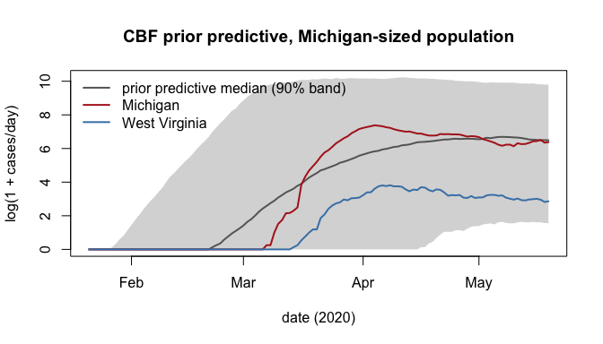

```r
theta_pp <- sample_prior(prior_cbf, n_pp)
mi <- expm1(sim_cbf(theta_pp, N_fixed = pop[["Michigan"]])[, -1, drop = FALSE])
env <- apply(log1p(mi), 2, stats::quantile, c(0.05, 0.5, 0.95))
dates <- start_date + t_grid - 1

plot(dates, env[2, ], type = "n", ylim = range(env), xlab = "date (2020)",
     ylab = "log(1 + cases/day)", main = "CBF prior predictive, Michigan-sized population")
polygon(c(dates, rev(dates)), c(env[1, ], rev(env[3, ])), col = "grey85", border = NA)
lines(dates, env[2, ], lwd = 2, col = "grey40")
lines(dates, log1p(case_daily_s["Michigan", ]), lwd = 2, col = "firebrick")
lines(dates, log1p(case_daily_s["West Virginia", ]), lwd = 2, col = "steelblue")
legend("topleft", bty = "n", lwd = 2, col = c("grey40", "firebrick", "steelblue"),
       legend = c("prior predictive median (90% band)", "Michigan", "West Virginia"))
```

## Train all three

One fit per model, each amortized across the whole prior — including the full range of state population sizes — and reused for all 51 jurisdictions. Train once, condition 51 times for the price of a forward pass each: that is what makes running three models across every state affordable.

```r
n_sim <- 15000
fits <- lapply(sims, function(m) {
  npe(m$prior, m$sim, n_simulations = n_sim, density_estimator = "maf",
      embedding_net = embed, max_epochs = 300, n_restarts = 1,
      seed = 1, verbose = FALSE)
})
fits$CBF
```

```
#> <nsbi_npe> Neural Posterior Estimation fit
#>   density estimator : maf
#>   parameters (dim)  : 8
#>     names           : beta[0], beta[B], g, r, mu[B], t[0], I[0], rho
#>   data (dim)        : 121
#>   embedding (mlp)   : 121 -> 12 features
#>   simulations       : 15000
#>   best val loss     : 2.6726
#>   -> build a posterior with posterior(fit, x_obs = ...)
```

## Validate before trusting a single curve

Simulation-based calibration (SBC) checks that each posterior’s credible intervals have the coverage they claim, using fresh prior draws the network never saw during training. For each of many simulated “true” parameter values we compute where that value ranks among posterior draws conditioned on the resulting simulated data; if the posterior is calibrated the rank is equally likely to fall anywhere, so the rank histogram should come out flat. Skew toward the edges means overconfidence; skew toward the middle, underconfidence.

```r
sbc_res <- lapply(names(fits), function(nm)
  sbc(fits[[nm]], sims[[nm]]$sim, n_sbc = 150, n_posterior_samples = 300, seed = 2))
names(sbc_res) <- names(fits)
sbc_res$CBF
```

```
#> <nsbi_sbc> 150 trials, 300 posterior samples each
#>   per-parameter uniformity p-values (large = calibrated):
#>     beta[0]=0.234  beta[B]=0.701  g=0.138  r=0.828  mu[B]=0.436  t[0]=0.768  I[0]=0.996  rho=0.855
```

Because each prior’s `mean` was a named vector, `sbc_res` carries those names and `plot_sbc()` renders them as their plotmath symbol directly in the panel title instead of a generic “parameter 3”.

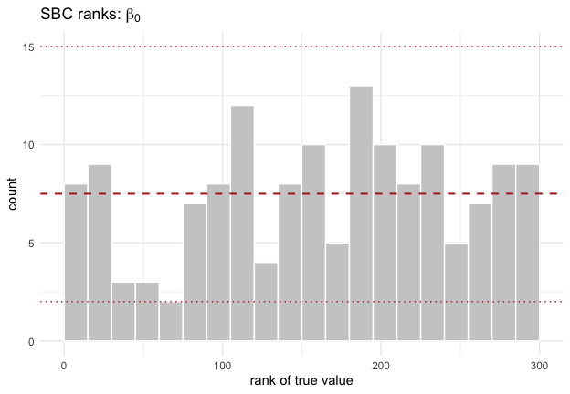

```r
plot_sbc(sbc_res$CBF, param = 1L)
```

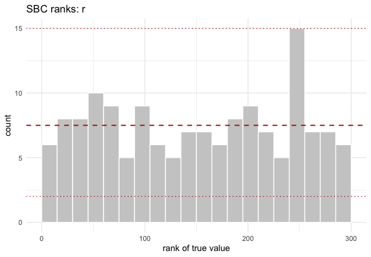

```r
plot_sbc(sbc_res$CBF, param = 4L)
```

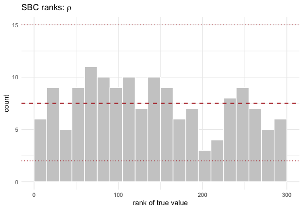

```r
plot_sbc(sbc_res$CBF, param = 8L)
```

## Posterior predictive: daily incidence, three models

Now the comparison that matters. For each state we condition each trained posterior on that state’s own daily curve and population, push the draws back through the simulator, and compare the predicted daily incidence to what was reported.

We summarize the predictive by its **median**, not its mean. Daily counts here span four orders of magnitude and the estimator is trained on $\log(1+x)$; the predictive distribution on each day is strongly right-skewed, so its mean tracks the upper tail rather than the center. Plotting the mean of a skewed count predictive makes a well-calibrated fit look like a systematic overshoot.

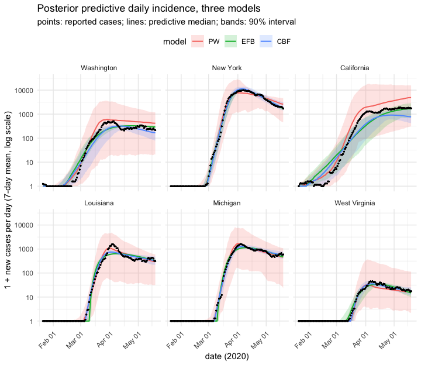

```r
highlight <- c("Washington", "New York", "California", "Louisiana", "Michigan", "West Virginia")
obs_for <- function(s) c(log(pop[[s]]), log1p(case_daily_s[s, ]))

pred_for <- function(nm, state, n_draws = 400) {
  post <- posterior(fits[[nm]], x_obs = obs_for(state))
  draws <- sample(post, n_draws)
  r <- sims[[nm]]$sim(draws, N_fixed = pop[[state]], full = TRUE)
  pred <- smooth7(r$reported)
  data.frame(model = nm, state = state, date = start_date + t_grid - 1,
             observed = case_daily_s[state, ],
             med = apply(pred, 2, stats::median),
             lo = apply(pred, 2, stats::quantile, 0.05),
             hi = apply(pred, 2, stats::quantile, 0.95))
}

pp <- do.call(rbind, lapply(names(fits), function(nm)
  do.call(rbind, lapply(highlight, function(s) pred_for(nm, s)))))
pp$state <- factor(pp$state, levels = highlight)
pp$model <- factor(pp$model, levels = c("PW", "EFB", "CBF"))

library(ggplot2)
# Plotted on a log axis, shifted by 1 to match the log1p scale the estimator
# is trained on. Daily counts run from a handful in West Virginia to five
# figures in New York; on a linear axis the widest band decides the y-range and
# every other curve is pressed flat against the bottom of the panel.
ggplot(pp, aes(date)) +
  geom_ribbon(aes(ymin = lo + 1, ymax = hi + 1, fill = model), alpha = 0.18) +
  geom_line(aes(y = med + 1, colour = model), linewidth = 0.7) +
  geom_point(aes(y = observed + 1), colour = "black", size = 0.35) +
  facet_wrap(~state, ncol = 3) +
  scale_x_date(date_labels = "%b %d") +
  scale_y_log10() +
  labs(x = "date (2020)", y = "1 + new cases per day (7-day mean, log scale)",
       title = "Posterior predictive daily incidence, three models",
       subtitle = "points: reported cases; lines: predictive median; bands: 90% interval") +
  theme_minimal() +
  theme(axis.text.x = element_text(angle = 45, hjust = 1),
        legend.position = "top")
```

The three bands differ strikingly in width — the piecewise model’s is an order of magnitude wider at New York’s peak than either behavioral model’s. It is tempting to read the narrow bands as overconfidence. They are not, and the way to tell is to hold $\theta$ *fixed* and re-simulate: whatever spread survives is the simulator’s own process noise, with no posterior uncertainty in it at all.

```r
# One representative theta per model (the coordinatewise posterior median --
# not necessarily a high-density point for a correlated posterior, but it
# produces a New-York-like epidemic, which is all this diagnostic needs).
noise_at_fixed_theta <- function(nm, state = "New York", n_rep = 300) {
  draws <- sample(posterior(fits[[nm]], x_obs = obs_for(state)), 500)
  one <- apply(draws, 2, stats::median)
  rep_theta <- matrix(rep(one, n_rep), nrow = n_rep, byrow = TRUE)
  r <- sims[[nm]]$sim(rep_theta, N_fixed = pop[[state]], full = TRUE)
  pred <- smooth7(r$reported)
  j <- which.max(case_daily_s[state, ])
  c(peak_cv = stats::sd(pred[, j]) / mean(pred[, j]),
    peak_day_sd = stats::sd(apply(pred, 1, which.max)))
}
round(t(sapply(names(fits), noise_at_fixed_theta)), 4)
```

```
#>     peak_cv peak_day_sd
#> PW   0.1673     10.3788
#> EFB  0.0048      0.8898
#> CBF  0.0145      0.8283
```

The open-loop piecewise model has roughly an order of magnitude more peak-height variability at fixed $\theta$ than either behavioral model. That is the feedback doing exactly what feedback does: run hot and $\beta$ falls, run cold and it recovers, so the loop damps the demographic noise that an open-loop model lets through. A behavioral epidemic model is therefore *intrinsically* more predictable than a phenomenological one at the same parameter values, and most of the narrow predictive band is mechanism rather than posterior. Whether the remaining width is honest is a question only SBC can answer — which is why the rank histograms above come before this plot, not after.

A quantitative score across all 51 states, not just the six plotted: the root-mean-square error of the predictive median against the observed curve, on the $\log(1+x)$ scale the estimator works in.

```r
score_state <- function(nm, state, n_draws = 300) {
  post <- posterior(fits[[nm]], x_obs = obs_for(state))
  r <- sims[[nm]]$sim(sample(post, n_draws), N_fixed = pop[[state]], full = TRUE)
  med <- apply(smooth7(r$reported), 2, stats::median)
  c(rmse = sqrt(mean((log1p(med) - log1p(case_daily_s[state, ]))^2)),
    attack = stats::median(1 - r$S_frac[, days]),
    R0 = stats::median(r$beta_eff[, 1]) / gamma_fixed)
}

scores <- do.call(rbind, lapply(names(fits), function(nm) {
  m <- t(sapply(state_names, function(s) score_state(nm, s)))
  data.frame(model = nm, rmse_med = median(m[, "rmse"]),
             rmse_iqr = paste(round(stats::quantile(m[, "rmse"], c(.25, .75)), 2), collapse = "-"),
             attack_med = median(m[, "attack"]),
             n_param = fits[[nm]]$dim_theta)
}))
scores
```

```
#>   model  rmse_med  rmse_iqr attack_med n_param
#> 1    PW 0.2352627  0.19-0.3 0.04166990      10
#> 2   EFB 0.2108746 0.15-0.29 0.02389311       6
#> 3   CBF 0.1757844 0.14-0.23 0.02538268       8
```

## R(t) for every state

The effective reproduction number is
$$R_e(t) \;=\; \frac{\beta(t)}{\gamma} \cdot \frac{S(t)}{N},$$
the average number of secondary cases per infection *given the susceptibles still available*. The $S(t)/N$ factor is not decoration: in New York the model infers that a substantial share of the population had been infected by mid-May, so $R_e$ there ends the window well below what the transmission rate alone would suggest. We compute both factors from the simulator’s own state trajectories rather than re-deriving $\beta(t)$ alongside it, so the reported quantity and the fitted model cannot drift apart. For the CBF model $\beta(t)$ is the transmission rate averaged over the susceptible pool, which mixes the unprotected and risk-averse compartments.

The model used below is whichever scored best above, not a fixed choice. The three are close enough that the winner can move with the simulation budget, so if you re-run this article with a different `n_sim` do not be surprised to see a different name here.

```r
best <- as.character(scores$model[which.min(scores$rmse_med)])
best
```

```
#> [1] "CBF"
```

```r
rt_state <- function(state, nm = best, n_draws = 400) {
  post <- posterior(fits[[nm]], x_obs = obs_for(state))
  r <- sims[[nm]]$sim(sample(post, n_draws), N_fixed = pop[[state]], full = TRUE)
  rt <- r$beta_eff / gamma_fixed * r$S_frac
  data.frame(state = state, date = start_date + t_grid - 1,
             rt_med = apply(rt, 2, stats::median),
             rt_lo = apply(rt, 2, stats::quantile, 0.05),
             rt_hi = apply(rt, 2, stats::quantile, 0.95),
             attack = stats::median(1 - r$S_frac[, days]))
}

rt_all <- do.call(rbind, lapply(state_names, rt_state))
```

The inferred attack rates are the sanity check on the ascertainment prior: what $\rho$ and the case counts jointly imply about how much of each state had actually been infected by 2020-05-19.

```r
attack_by_state <- tapply(rt_all$attack, rt_all$state, `[`, 1)
round(quantile(attack_by_state, c(0, 0.25, 0.5, 0.75, 1)), 4)
```

```
#>     0%    25%    50%    75%   100%
#> 0.0044 0.0158 0.0263 0.0529 0.2541
```

```r
round(sort(attack_by_state, decreasing = TRUE)[1:5], 3)
```

```
#>             New York           New Jersey         Rhode Island
#>                0.254                0.217                0.208
#>        Massachusetts District of Columbia
#>                0.177                0.137
```

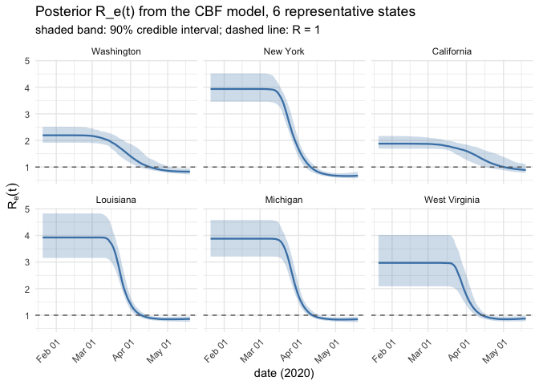

```r
rt_h <- rt_all[rt_all$state %in% highlight, ]
rt_h$state <- factor(rt_h$state, levels = highlight)

ggplot(rt_h, aes(date, rt_med)) +
  geom_ribbon(aes(ymin = rt_lo, ymax = rt_hi), fill = "steelblue", alpha = 0.25) +
  geom_line(colour = "steelblue", linewidth = 0.8) +
  geom_hline(yintercept = 1, linetype = 2, colour = "grey40") +
  facet_wrap(~state, ncol = 3) +
  scale_x_date(date_labels = "%b %d") +
  labs(x = "date (2020)", y = expression(R[e](t)),
       title = paste0("Posterior R_e(t) from the ", best, " model, 6 representative states"),
       subtitle = "shaded band: 90% credible interval; dashed line: R = 1") +
  theme_minimal() +
  theme(axis.text.x = element_text(angle = 45, hjust = 1))
```

All 51 jurisdictions, condensed into one view.

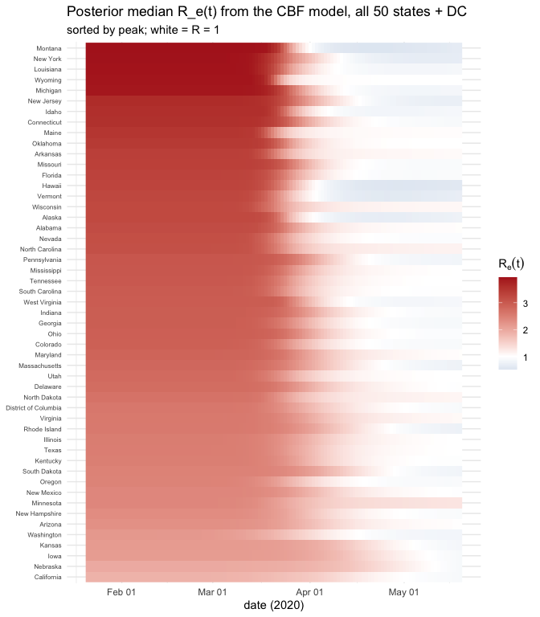

```r
peak_order <- names(sort(tapply(rt_all$rt_med, rt_all$state, max), decreasing = TRUE))
rt_all$state <- factor(rt_all$state, levels = rev(peak_order))

ggplot(rt_all, aes(date, state, fill = rt_med)) +
  geom_raster() +
  scale_fill_gradient2(midpoint = 1, low = "steelblue", mid = "white",
                       high = "firebrick", name = expression(R[e](t))) +
  scale_x_date(date_labels = "%b %d") +
  labs(x = "date (2020)", y = NULL,
       title = paste0("Posterior median R_e(t) from the ", best, " model, all 50 states + DC"),
       subtitle = "sorted by peak; white = R = 1") +
  theme_minimal() +
  theme(axis.text.y = element_text(size = 6))
```

## What this comparison bought

The alternative to amortized NPE is fitting each model to each state separately — 153 particle filters or MCMC chains, 153 opportunities for one to fail to converge. Here, training happened three times (1.5 × 10<sup>4</sup> simulations each), and every state’s posterior under every model cost a forward pass.

Three lessons generalize past this dataset.

*Do not leave the epidemic’s phase to demographic noise.* A branching process started from a couple of infections and run for four months has a final size spread across orders of magnitude and a takeoff time that wanders by weeks. If nothing in $\theta$ can absorb that, the posterior predictive integrates over it, and its mean sits far above the data while its 5th percentile sits at zero. Inferring $(t_0, I_0)$ fixes it, and the recovered introduction days are a free check on the change: the posterior puts New York’s near March 1 and West Virginia’s in mid-March, matching when those states actually reported their first cases.

*Do not let case counts alone set the epidemic’s scale.* They identify $\rho \times \text{incidence}$. Without external information on $\rho$ the fit slides along that ridge toward vast, barely-ascertained epidemics, because susceptible depletion is then available to flatten the peak. Seroprevalence data break the tie, and they belong in the prior.

*A mechanism can be cheaper than a curve fit.* The piecewise model needs 10 parameters to bend $\beta(t)$ into the right shape and, having no mechanism, happily reports transmission rates for regimes that ended before the state’s epidemic began. The behavioral models get comparable fits from 6 and 8 parameters and put a physical interpretation on every one of them.

One structural difference between the two behavioral models deserves stating, because it is invisible in a 120-day first-wave window and decisive outside one. EFB’s denominator contains the *cumulative* case count, which only ever grows, so its $\beta(t)$ is monotone non-increasing: the model can bend an epidemic down but can never let it come back. CBF can, because $\mu_B$ lets risk-averse individuals drift back into the susceptible pool once incidence falls. Over the first wave the two look similar; over a second wave they could not, and this is the likeliest reason the original study found CBF the better forecaster.

The models still carry real simplifications, worth stating plainly. $\gamma$ is fixed rather than inferred, so `sbc()` above is calibrated conditional on that choice, not unconditionally. A single ascertainment rate $\rho$ stands in for what was, in practice, a patchwork of state and local testing capacity that grew steeply over exactly this window; a time-varying $\rho(t)$ is the obvious next refinement, at the cost of a parameter confounded with transmission. Each state gets one introduction, whereas states with large international airports saw a trickle of imported cases for weeks before community transmission established — California, whose first weeks carry a handful of traveler-associated cases, is the state every model here fits worst. The behavioral models assume the whole state reacts to a single statewide case count, which is a strong assumption for California and a mild one for Rhode Island. And Louisiana’s Mardi Gras superspreading produced a spike that a smooth behavioral response cannot reproduce. Loosening any of these is a change to the simulator, not to the inference machinery around it — the same amortized-NPE workflow applies unchanged.

For the underlying workflow in more depth, see `vignette("sir-epidemic")`, `vignette("diagnostics")`, and `vignette("density-estimators")`.